# Practical I: epidemiological surveillance and modelling (non-spatial)

26/27th January

In this first practical the student is expected to learn about epidemiological case count data and standard techniques to visualise and analyse them. Further, the student is expected to reflect on the issues these data present and provide a perspective on how to improve disease surveillance in order to better estimate epidemiological parameters in the future.

The practical will start with a short 15-20 minute presentation by the course convenor and demonstrators. The next 2h will be spent answering predefined questions before a short wrap up and reflection at the end.

## Practical I Questions

#### Q1: How is public health surveillance for infectious diseases defined? (ca. 5 minutes)

#### Q2: What are common disease surveillance data and what are their pros and cons? Name 4 at most. (ca. 15 minutes)

#### Q3: What are some of the common challenges with public health surveillance at the beginning of disease outbreaks? (ca. 5 minutes)

#### Q4: Describe the key data sources necessary to estimate the time-varying reproduction number Rt: https://academic.oup.com/aje/article/178/9/1505/89262? (ca. 20 minutes)

#### Q5: Please install the R-package ‘EpiEstim’ and load it (https://cran.r-project.org/web/packages/EpiEstim/index.html), and familiarize yourself with the documentation. Remove any objects from your workspace. Copy the code to install the package below. (ca. 15 min)

#### Q6: Install the most used visualisation package in R that is recommended by ‘EpiEstim’

#### Q7: Load and visualise flu incidence data contained in the package. Add a Figure legend to the plot.

#### Q8: Estimating Rt.

We can run estimate_R on the incidence data to estimate the reproduction number R. For this, we need to specify i) the time window(s) over which to estimate Rt and ii) information on the distribution of the serial interval.

For i), the default behavior is to estimate Rt over weekly sliding windows. This can be changed through the config$t_start and config$t_end arguments (see below, “Changing the time windows for estimation”). For ii), there are several options, specified in the method argument.

The simplest is the parametric_si method, where you only specify the mean and standard deviation of the SI.

In this example, we only specify the mean and standard deviation of the serial interval. In the following example, we use the mean (2.6 days) and standard deviation (1.5) of the serial interval for flu from Ferguson et al., Nature, 2005: https://www.nature.com/articles/nature04017

Export plot and describe each panel. (ca. 10 minutes)

```r
res_parametric_si <- estimate_R(Flu2009$incidence,
method="parametric_si",
config = make_config(list(
mean_si = 2.6, std_si = 1.5)))
head(res_parametric_si$R)
```

|  | t_start | t_end | Mean(R) | Std(R) | Quantile.0.025(R) | Quantile.0.05(R) | Quantile.0.25(R) | Median(R) | Quantile.0.75(R) | Quantile.0.95(R) | Quantile.0.975(R) |
| --- | --- | --- | --- | --- | --- | --- | --- | --- | --- | --- | --- |
| 1 | 2 | 8 | 1.735798 | 0.4091314 | 1.0287437 | 1.121933 | 1.445198 | 1.703761 | 1.991520 | 2.458972 | 2.624781 |
| 2 | 3 | 9 | 1.749168 | 0.3647267 | 1.1088223 | 1.195480 | 1.491345 | 1.723884 | 1.979457 | 2.389121 | 2.533119 |
| 3 | 4 | 10 | 1.537058 | 0.3074116 | 0.9947030 | 1.068694 | 1.320090 | 1.516613 | 1.731761 | 2.075176 | 2.195540 |
| 4 | 5 | 11 | 1.431839 | 0.2705921 | 0.9514466 | 1.017661 | 1.241251 | 1.414830 | 1.603900 | 1.904047 | 2.008849 |
| 5 | 6 | 12 | 1.422725 | 0.2515046 | 0.9731426 | 1.035808 | 1.245996 | 1.407932 | 1.583340 | 1.860107 | 1.956336 |
| 6 | 7 | 13 | 1.635373 | 0.2523436 | 1.1786332 | 1.243590 | 1.458847 | 1.622413 | 1.797779 | 2.071372 | 2.165745 |

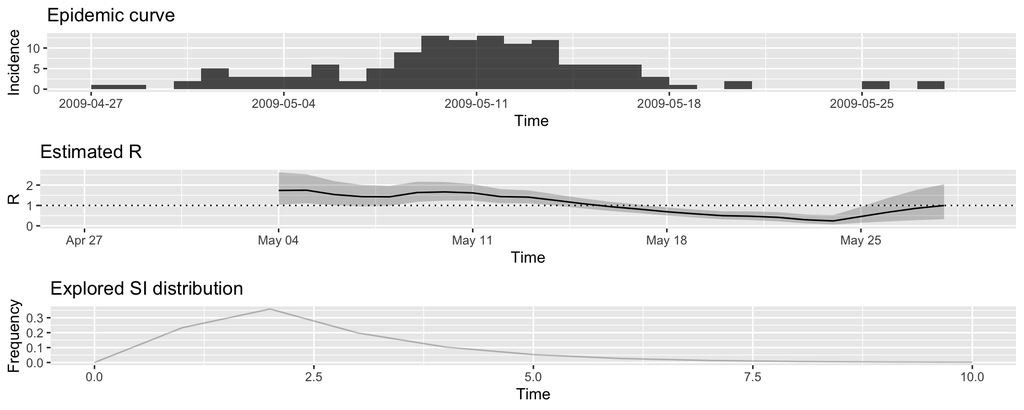

```r
plot(res_parametric_si, legend = FALSE)
```

#### Q9: Based on the above plot, describe the epidemiological dynamics of the outbreak by referencing the change in the time-varying reproduction number, Rt. (ca. 10 minutes)

#### Q10: Estimating R with a non parametric serial interval distribution

If one already has a full distribution of the serial interval, and not only a mean and standard deviation, this can be fed into estimate_r as follows.

Plot serial interval distribution and outputs from this model. Provide a perspective on what the SI distribution means for estimating transmission. (ca. 15 minutes)

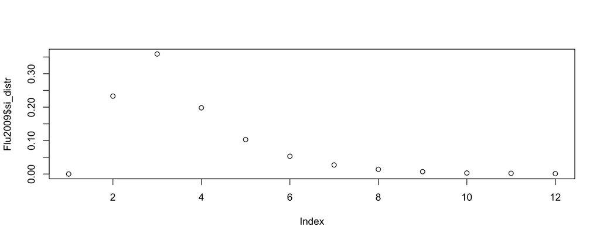

```r
plot(Flu2009$si_distr)
```

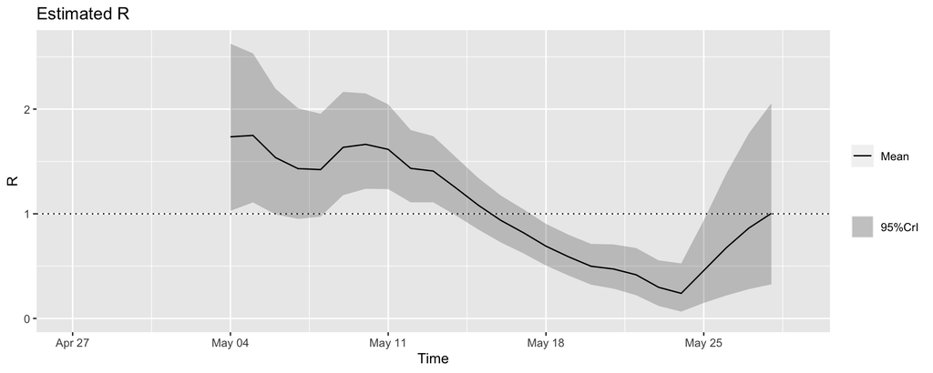

```r
res_non_parametric_si <- estimate_R(Flu2009$incidence, method="non_parametric_si",
config = make_config(list(si_distr = Flu2009$si_distr)))
plot(res_non_parametric_si, "R")
```

#### Q11: Estimating R accounting for uncertainty on the serial interval distribution

Sometimes, especially early in outbreaks, the serial interval distribution can be poorly specified. Therefore estimate_R also allows integrating results over various distributions of the serial interval. To do so, the mean and sd of the serial interval are each drawn from truncated normal distributions, with parameters specified by the user, as in the example below:

We choose to draw:

- The mean of the SI in a Normal(2.6, 1), truncated at 1 and 4.2
- The sd of the SI in a Normal(1.5, 0.5), truncated at 0.5 and 2.5

Provide the outputs from the model and describe the bottom plot in light of the uncertainty about the SI distribution.

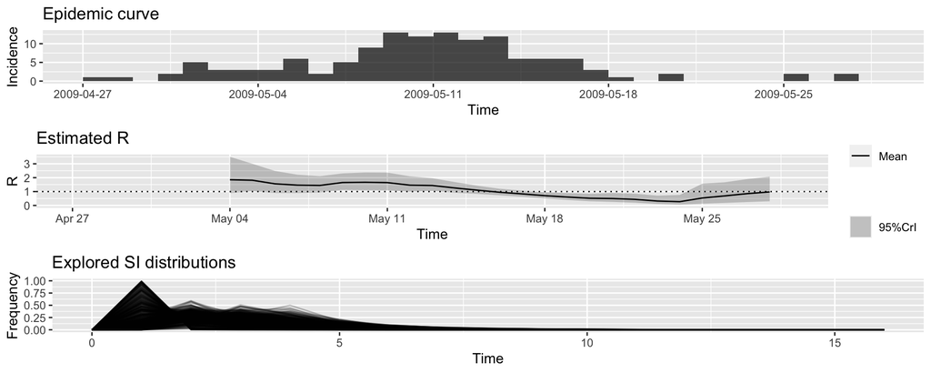

```r
config <- make_config(list(mean_si = 2.6, std_mean_si = 1,
min_mean_si = 1, max_mean_si = 4.2,
std_si = 1.5, std_std_si = 0.5,
min_std_si = 0.5, max_std_si = 2.5))
res_uncertain_si <- estimate_R(Flu2009$incidence,
method = "uncertain_si", config = config)
plot(res_uncertain_si)
```

#### Q12: Changing the time windows for estimation

Describe how the estimate of Rt compares to previous estimates (ca. 15 minutes):

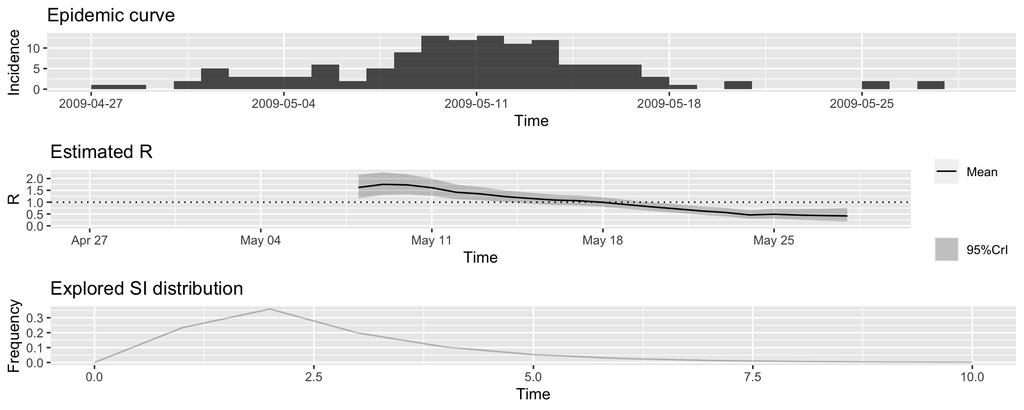

```r
T <- nrow(Flu2009$incidence)
t_start <- seq(2, T-10)
t_end <- t_start + 10 # adding 10 to get 11-day windows as bounds included in window
res_weekly <- estimate_R(Flu2009$incidence,
method="parametric_si",
config = make_config(list(t_start = t_start,
t_end = t_end,mean_si = 2.6, std_si = 1.5)))
plot(res_weekly)
```

#### Q13: Specifying imported cases

All of the above assumes that all cases are linked by local transmission. Sometimes you may have information (from field epidemiological investigations for instance) indicating that some cases are in fact imported (from another location, or from an animal reservoir). We allow to include such information, when available, as illustrated in the example below: generating fake information on our cases:

Compare estimates of Rt for this model compared to earlier models that do not consider imported cases. What is the impact on local Rt? (ca. 15 minutes)

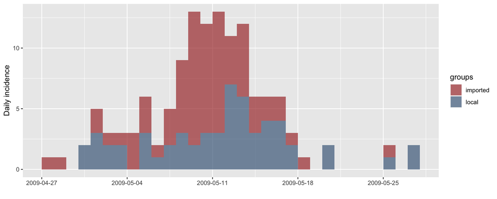

```r
dates_onset <- Flu2009$incidence$dates[unlist(lapply(1:nrow(Flu2009$incidence),
  function(i)
  rep(i, Flu2009$incidence$I[i])))]

location <- sample(c("local","imported"), length(dates_onset), replace=TRUE)

location[1] <- "imported" # forcing the first case to be imported

## get incidence per group (location)
incid <- incidence(dates_onset, groups = location)

plot(incid)
```

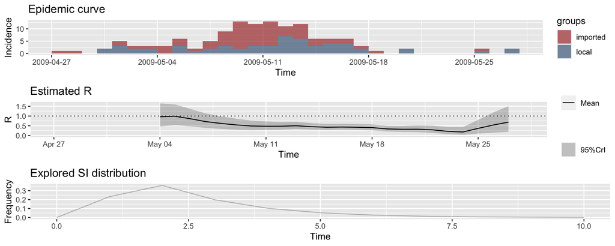

```r
## Estimate R with assumptions on serial interval:
res_with_imports <- estimate_R(incid, method = "parametric_si",
config = make_config(list(mean_si = 2.6, std_si = 1.5)))

# Default config will estimate R on weekly sliding windows.
# To change this change the t_start and t_end arguments.
plot(res_with_imports, add_imported_cases=TRUE)
```

#### Q14: Compare estimates of Rt for this model compared to earlier models that do not consider imported cases. What is the impact on local Rt? (ca. 15 minutes)

#### Q15: Some reflections on what we have learned